# PERSUADE OUTPUT

Authors

2020-07-02

# 1 Kaplan-Meier

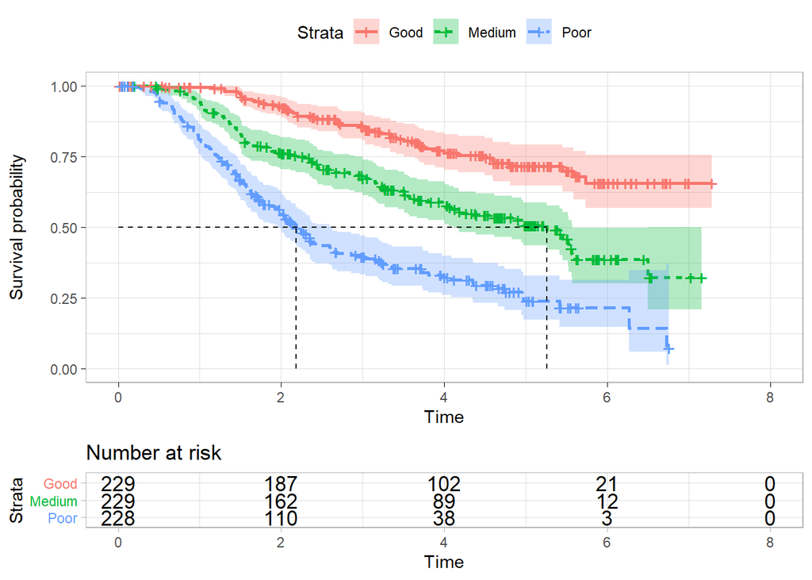

# 2 Stratified models?

Should stratified parametric survival models be used?

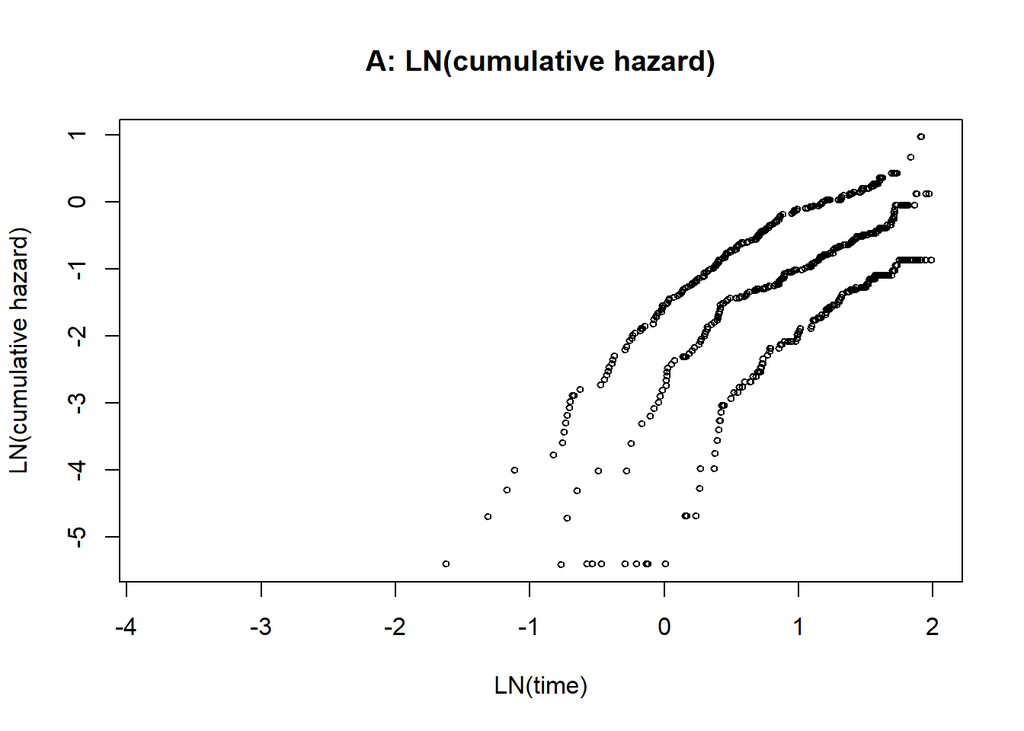

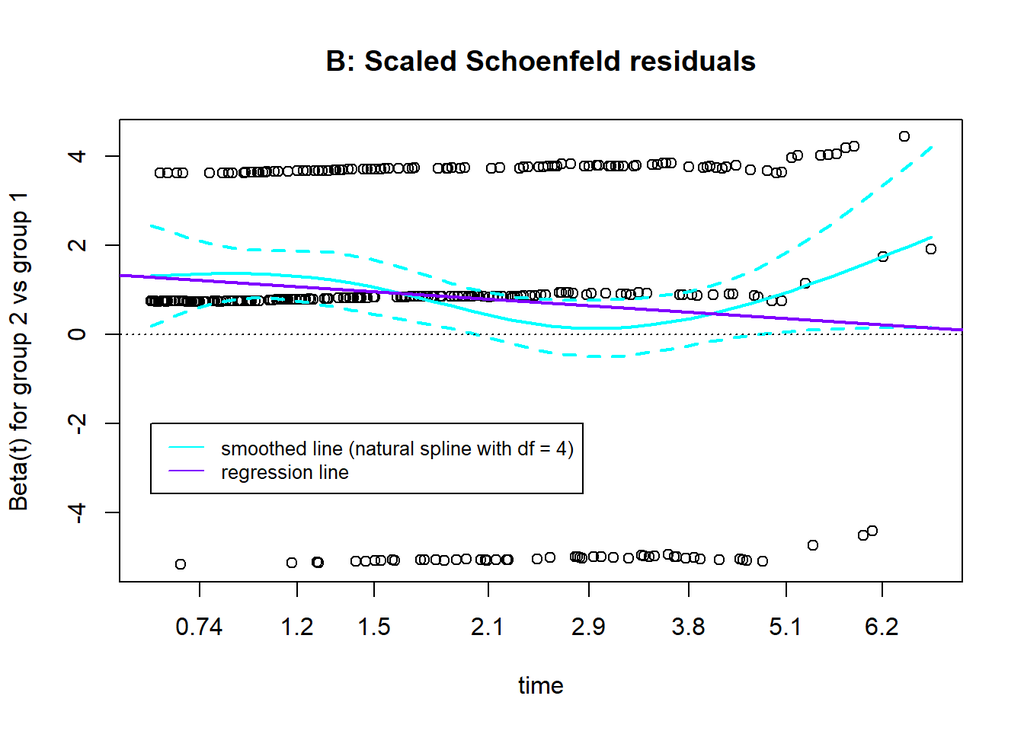

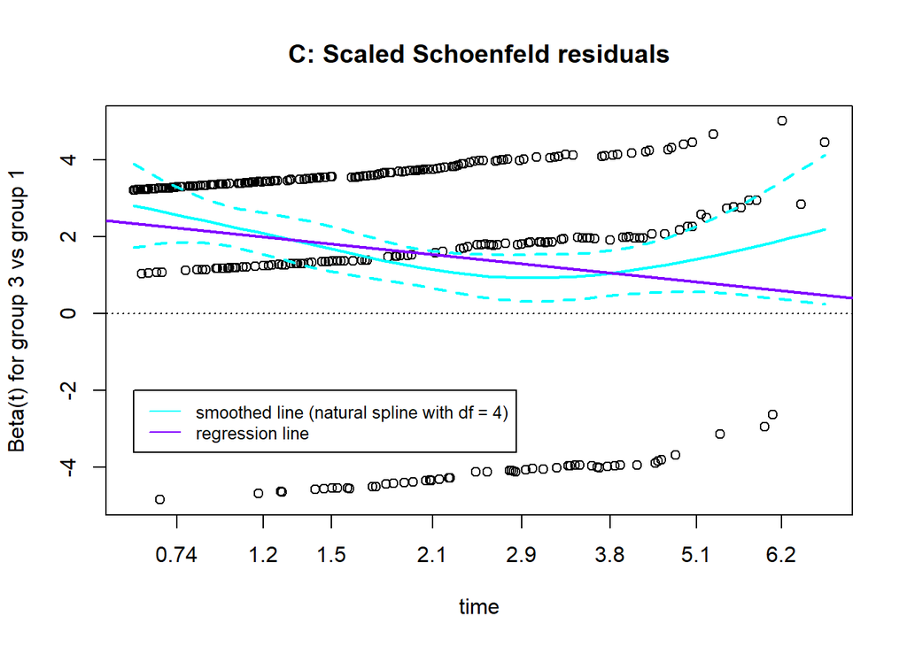

# 3 Monotonic hazard models?

Should parametric survival models assuming a monotonic hazard rate (i.e. exponential, Weibull, Gompertz) be used?

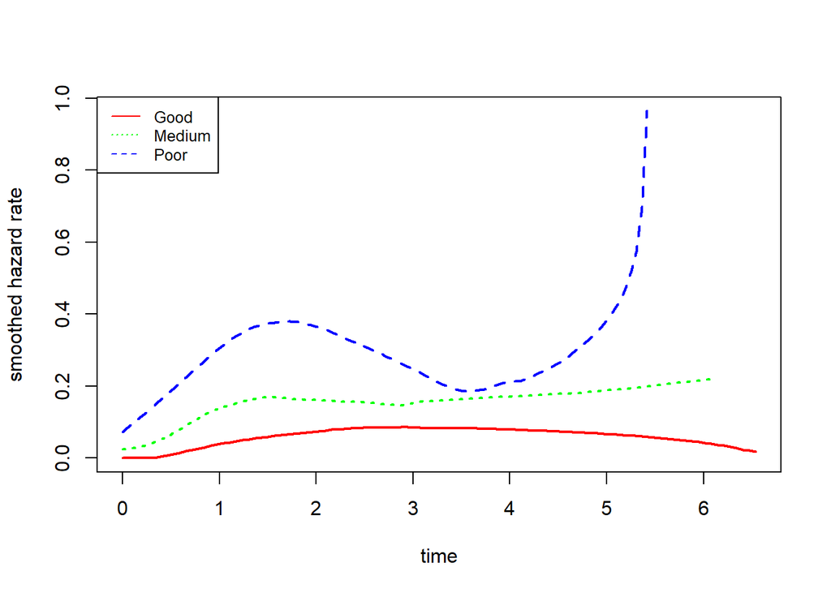

# 4 Standard parametric models?

Do standard parametric models provide an appropriate fit to the data?

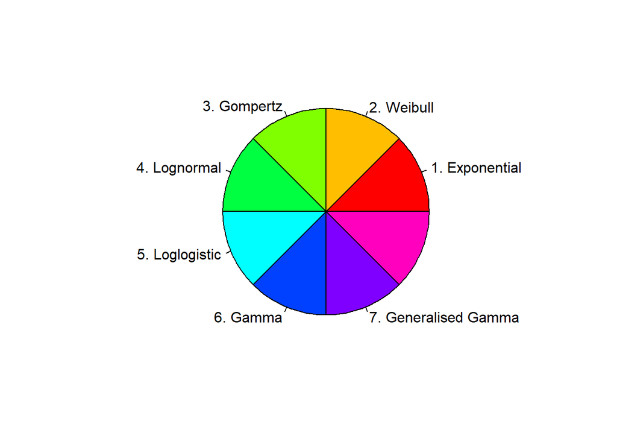

|  | Distribution | AIC | BIC |
| --- | --- | --- | --- |
| 7 | ggam | 1589.049 | 1629.826 |
| 4 | lnorm | 1592.880 | 1620.066 |
| 5 | llog | 1609.294 | 1636.479 |
| 6 | gam | 1621.982 | 1649.167 |
| 2 | weib | 1632.618 | 1659.803 |
| 3 | gom | 1660.954 | 1688.140 |
| 1 | exp | 1668.212 | 1681.805 |

## 4.1 Exponential

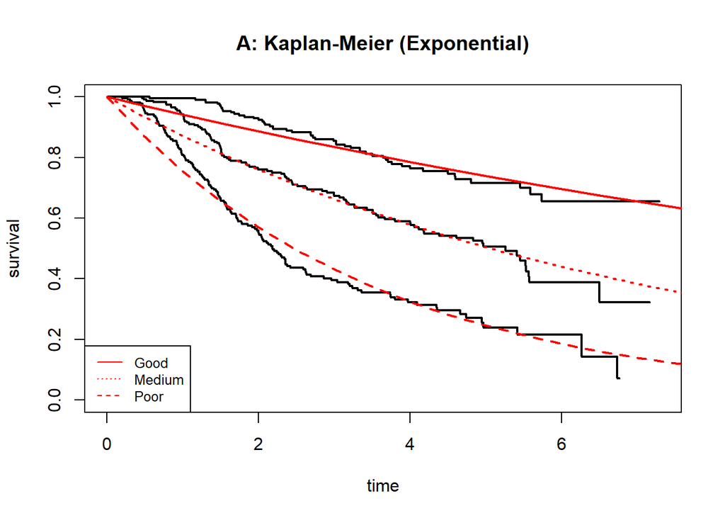

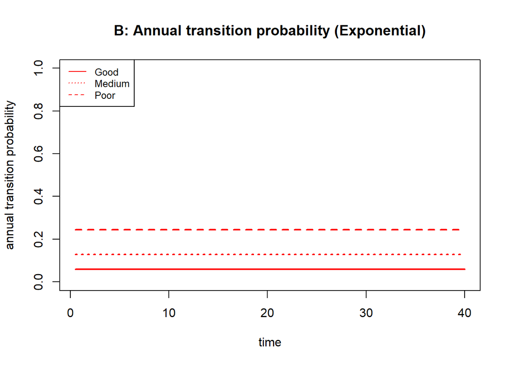

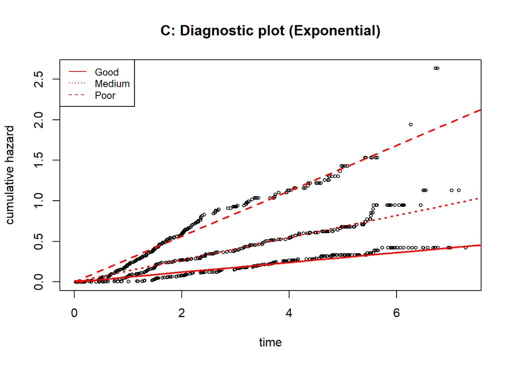

## 4.2 Weibull

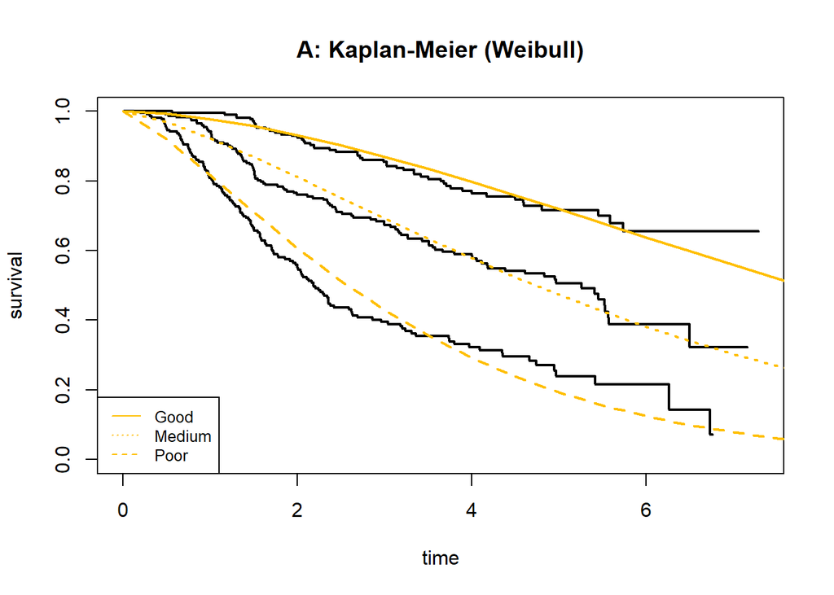

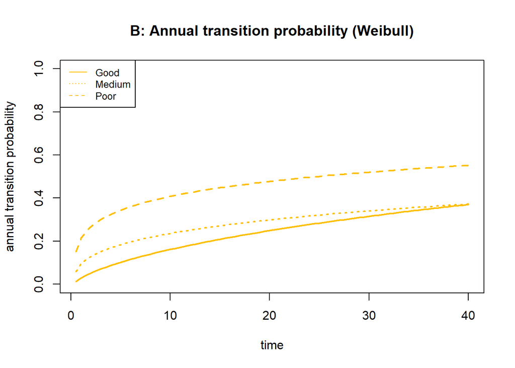

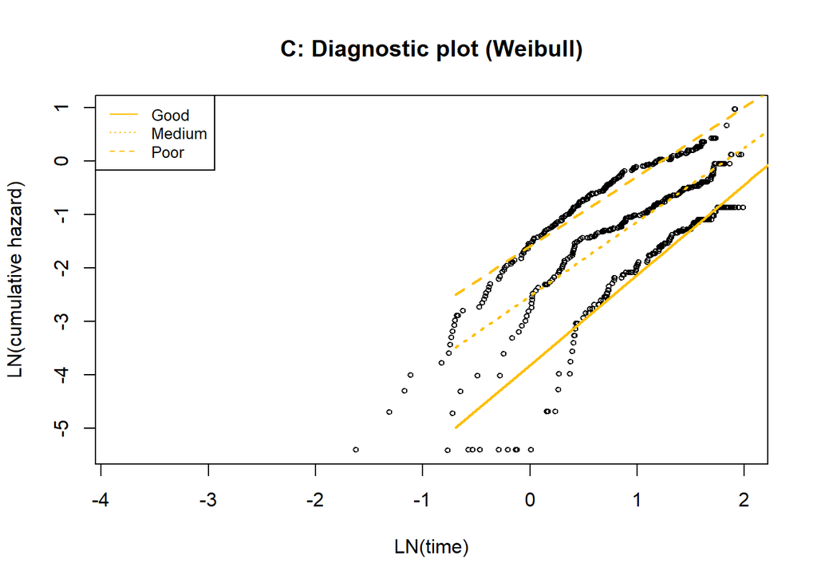

## 4.3 Gompertz

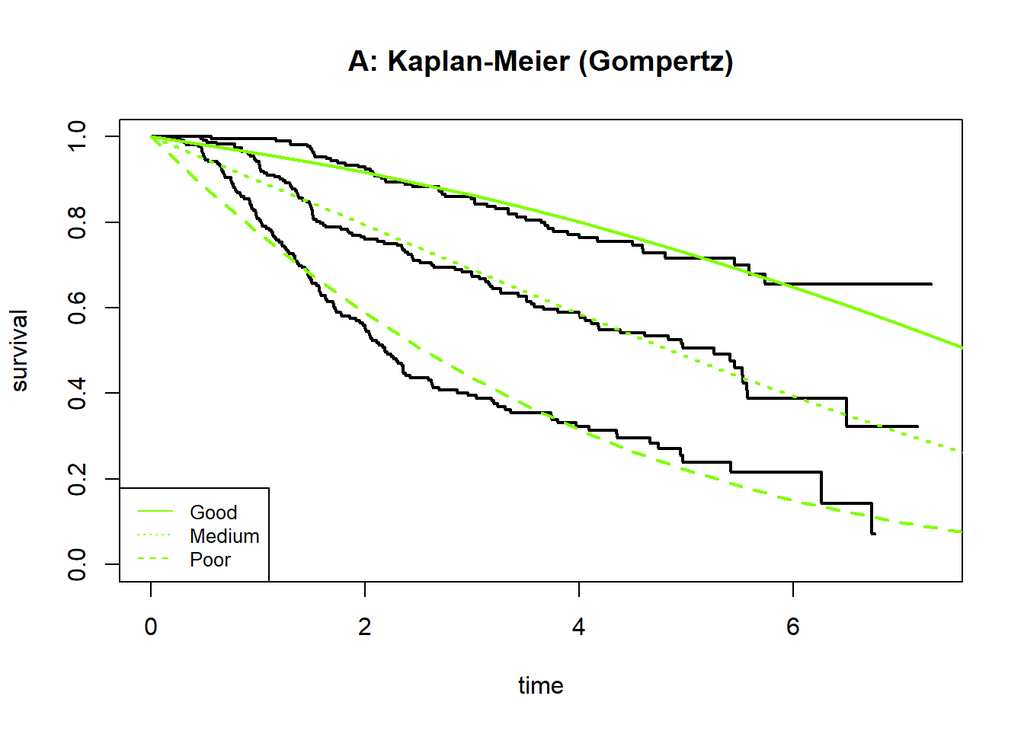

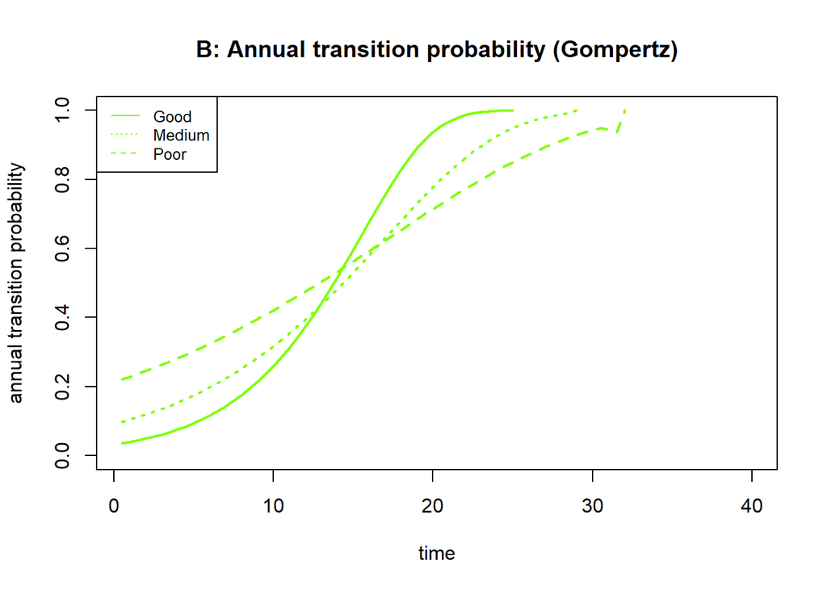

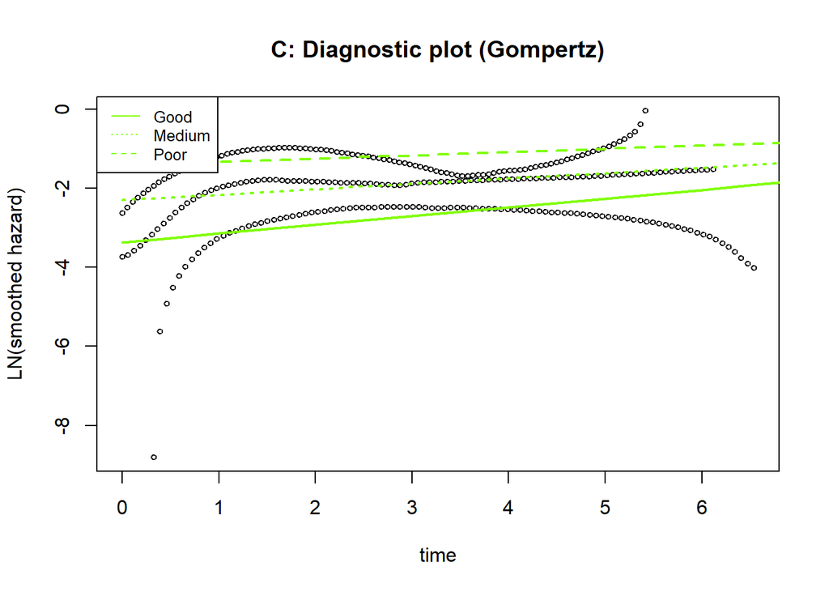

## 4.4 Lognormal

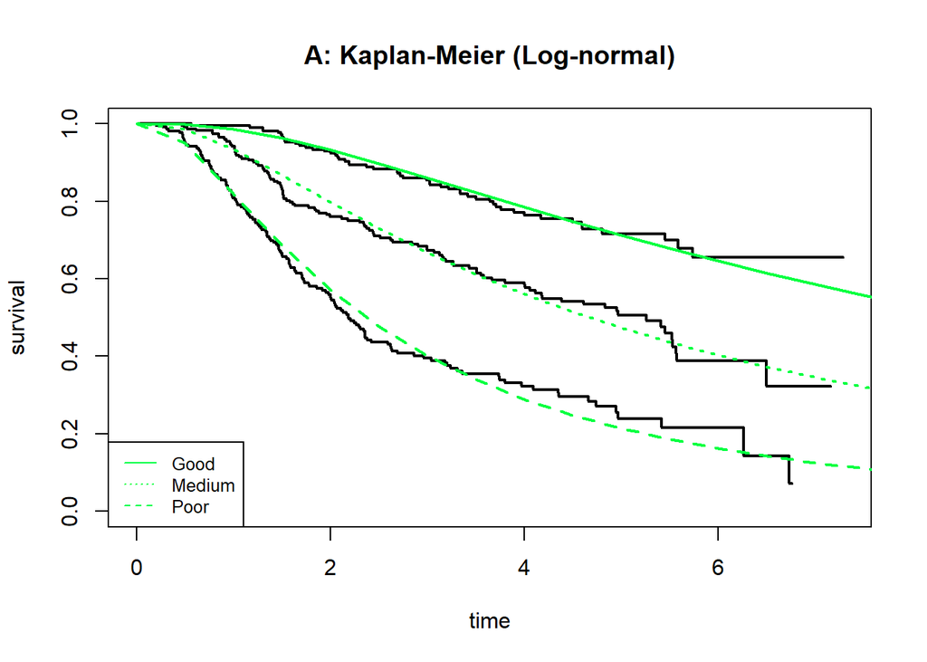

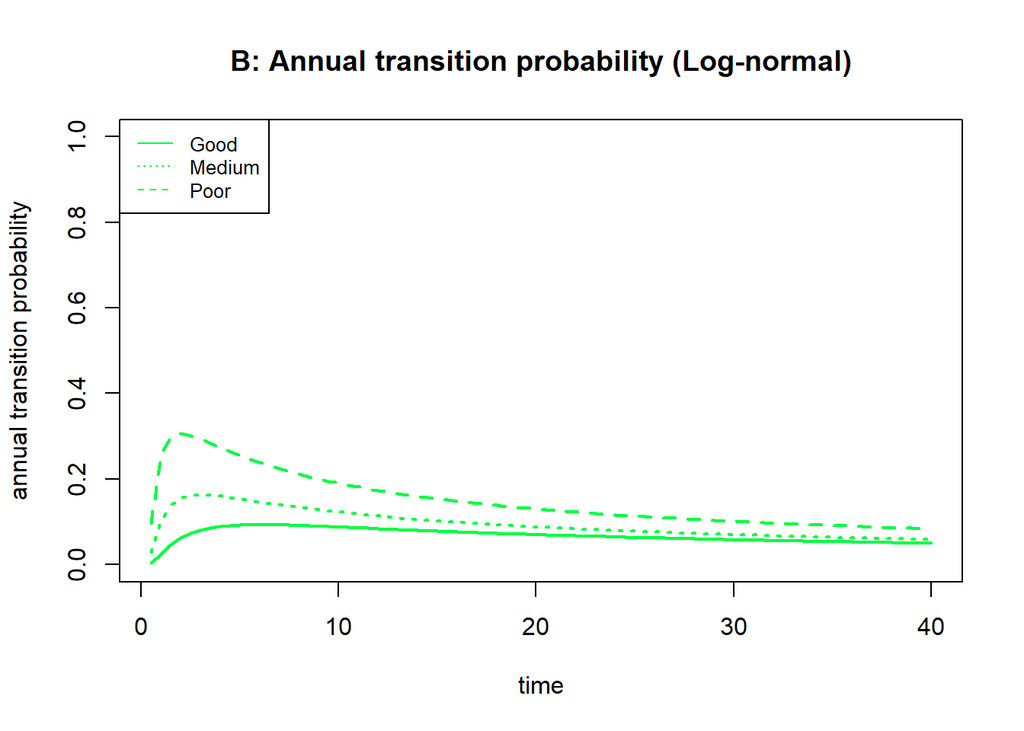

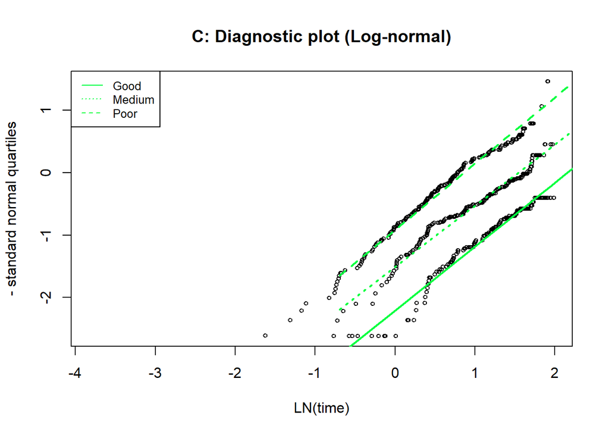

## 4.5 Loglogistic

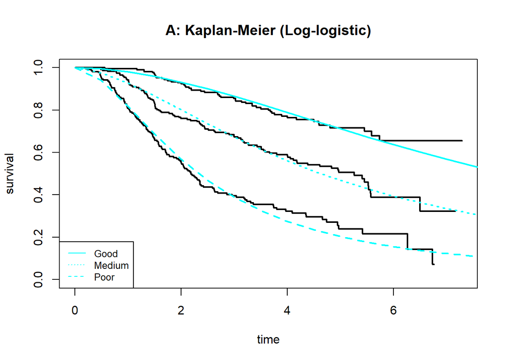

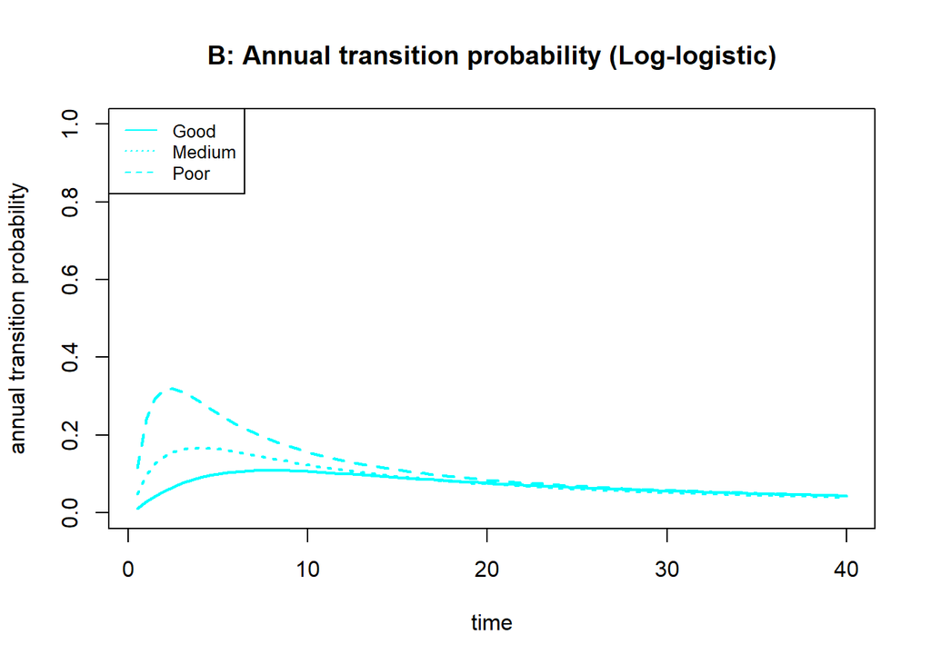

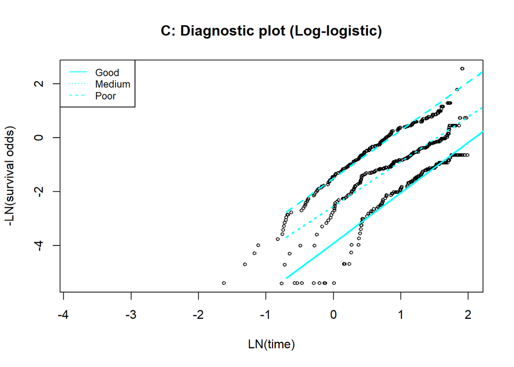

## 4.6 Gamma

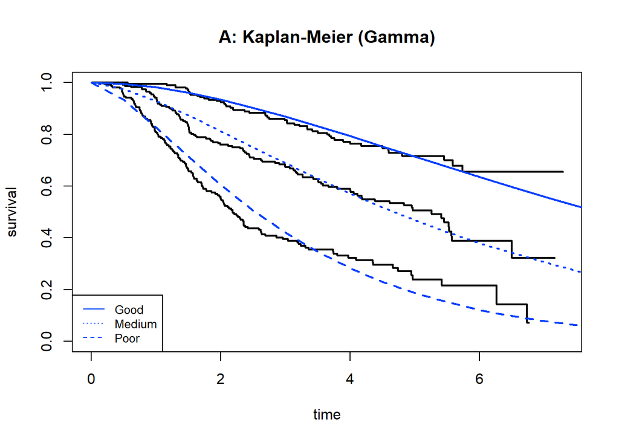

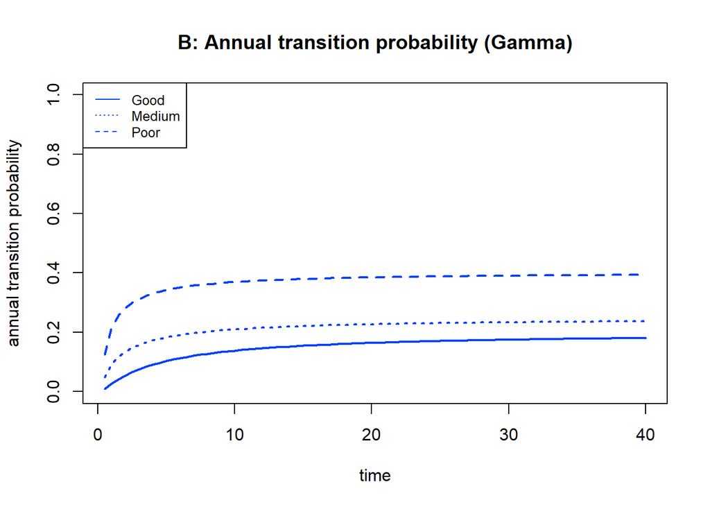

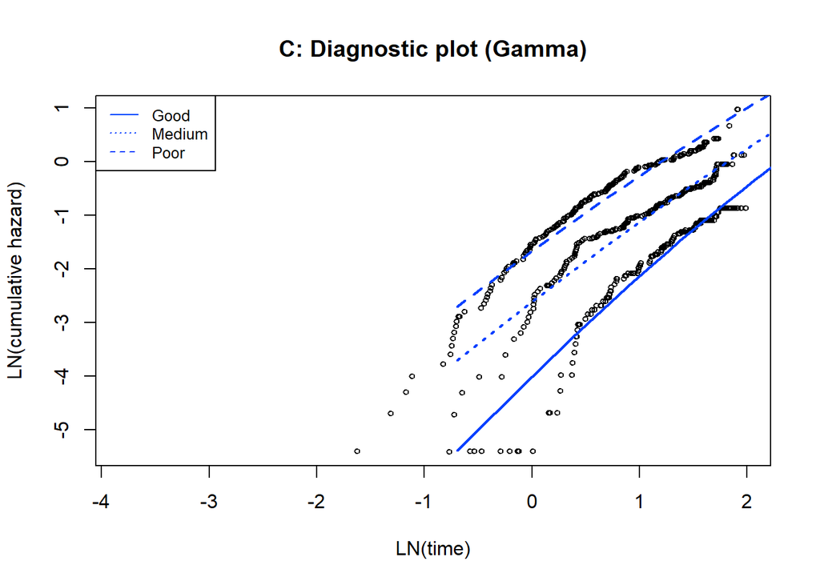

## 4.7 Generalised Gamma

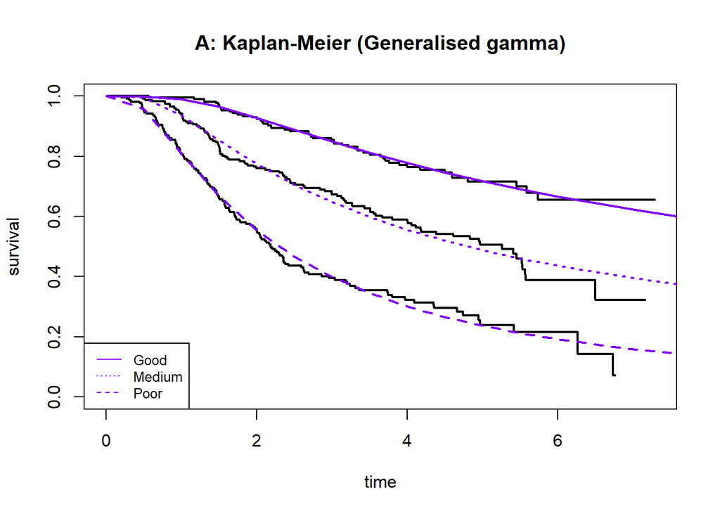

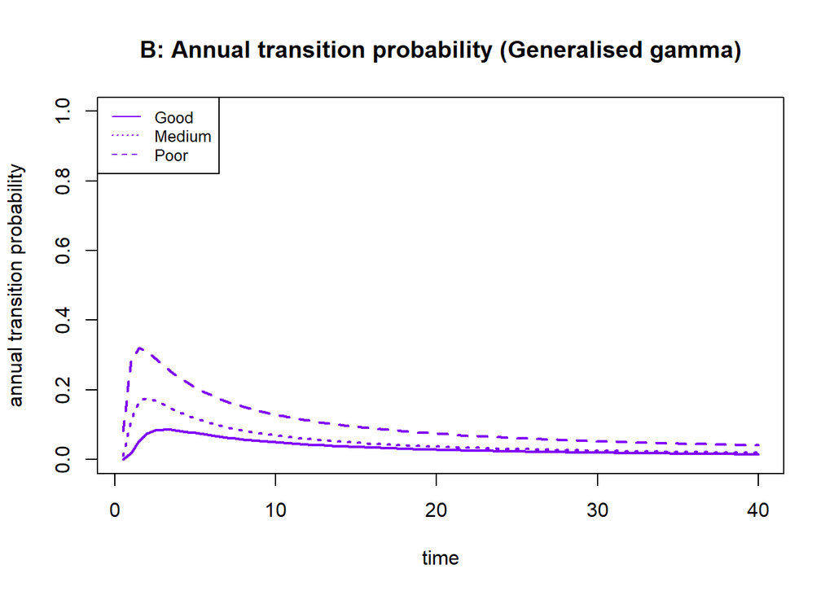

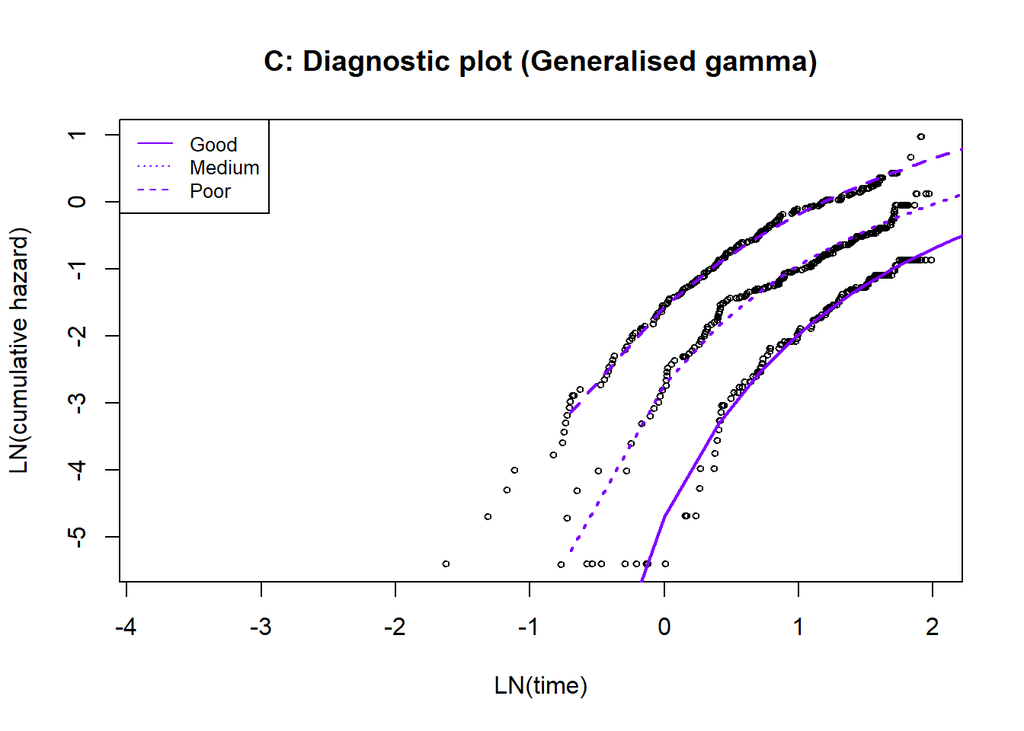

# 5 Parametric spline models?

If standard parametric models are not appropriate, are spline models a more appropriate fit to the data?

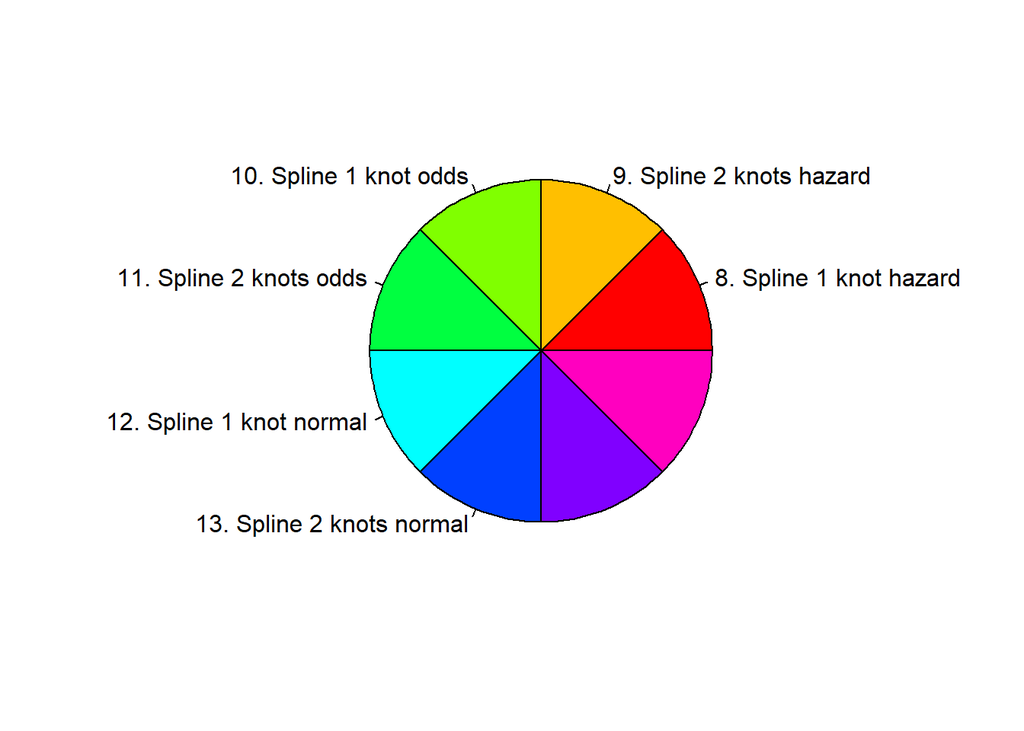

|  | Distribution | AIC | BIC |
| --- | --- | --- | --- |
| 7 | ggam | 1589.049 | 1629.826 |
| 4 | lnorm | 1592.880 | 1620.066 |
| 5 | llog | 1609.294 | 1636.479 |
| 6 | gam | 1621.982 | 1649.167 |
| 2 | weib | 1632.618 | 1659.803 |
| 3 | gom | 1660.954 | 1688.140 |
| 1 | exp | 1668.212 | 1681.805 |

|  | Scale | knots | AIC | BIC |
| --- | --- | --- | --- | --- |
| 4 | hazard | 2 | 1585.894 | 1640.264 |
| 5 | odds | 2 | 1587.289 | 1641.659 |
| 3 | normal | 1 | 1587.682 | 1628.460 |
| 6 | normal | 2 | 1588.343 | 1642.714 |
| 1 | hazard | 1 | 1589.327 | 1630.105 |
| 2 | odds | 1 | 1590.221 | 1630.999 |

## 5.1 Spline hazard 1 knot

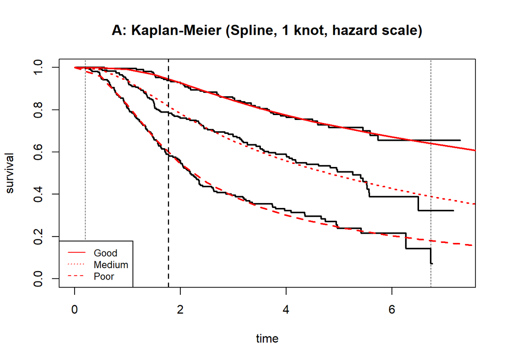

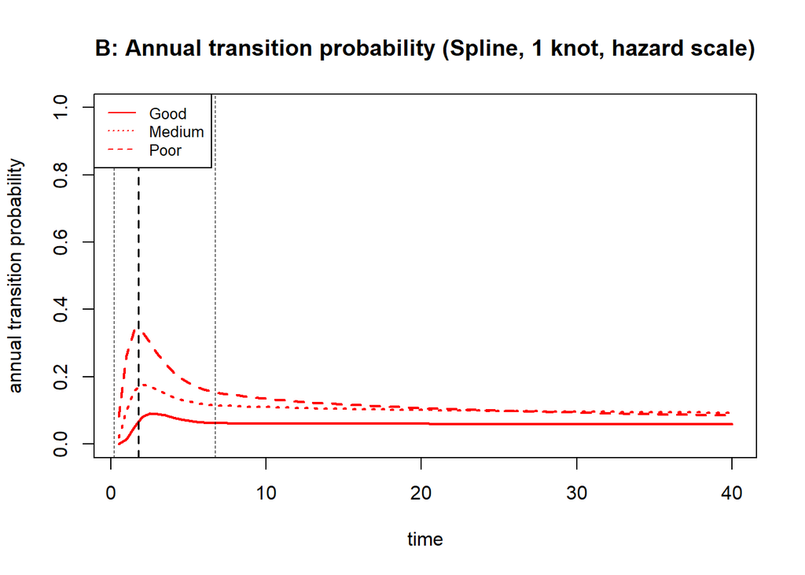

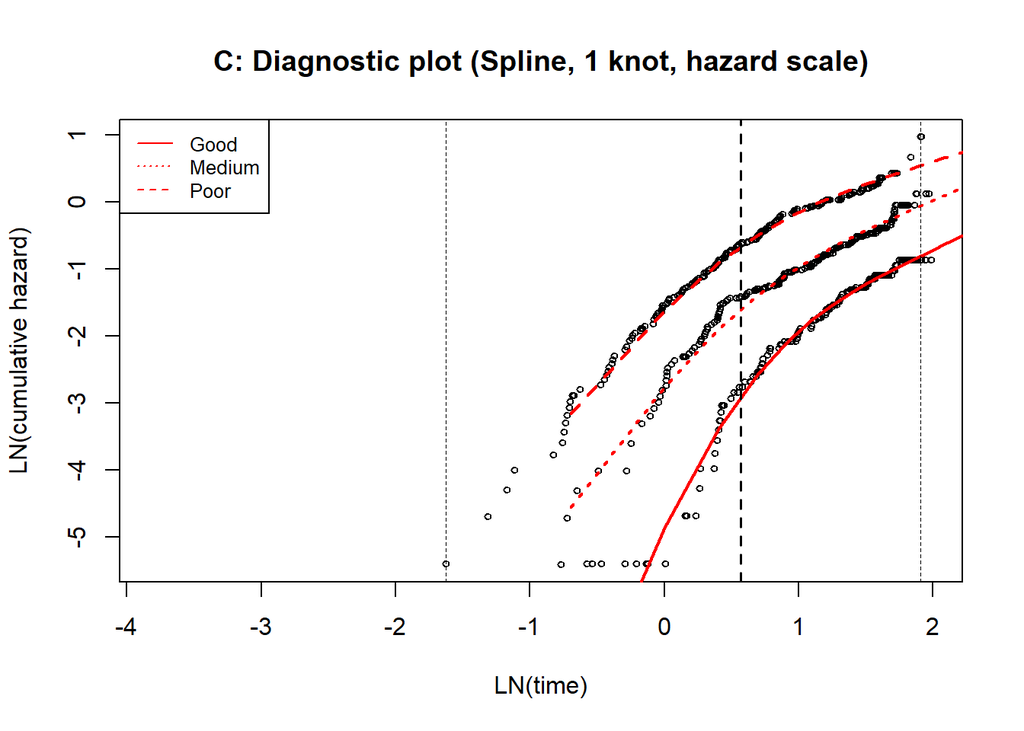

## 5.2 Spline hazard 2 knots

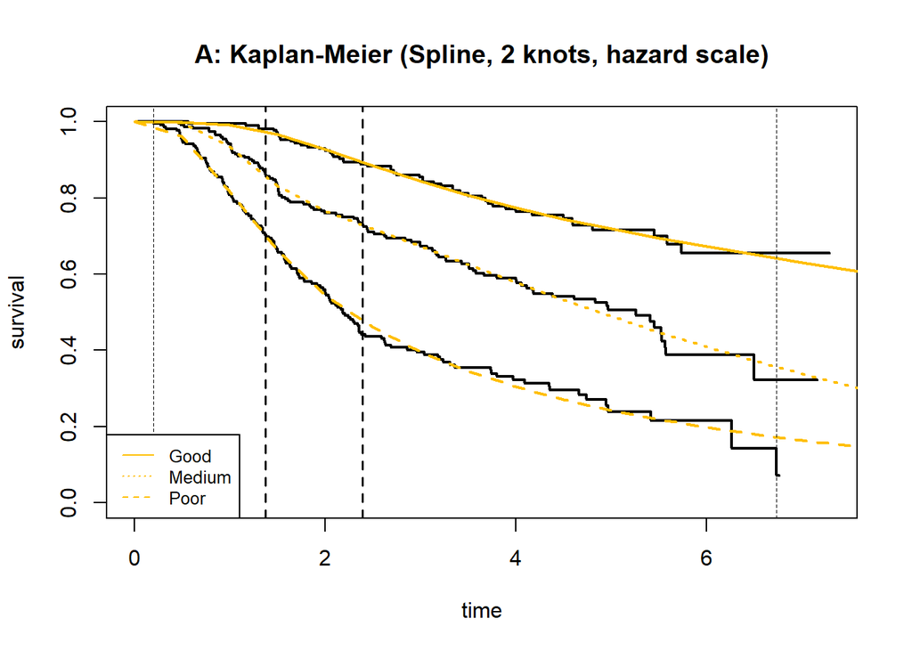

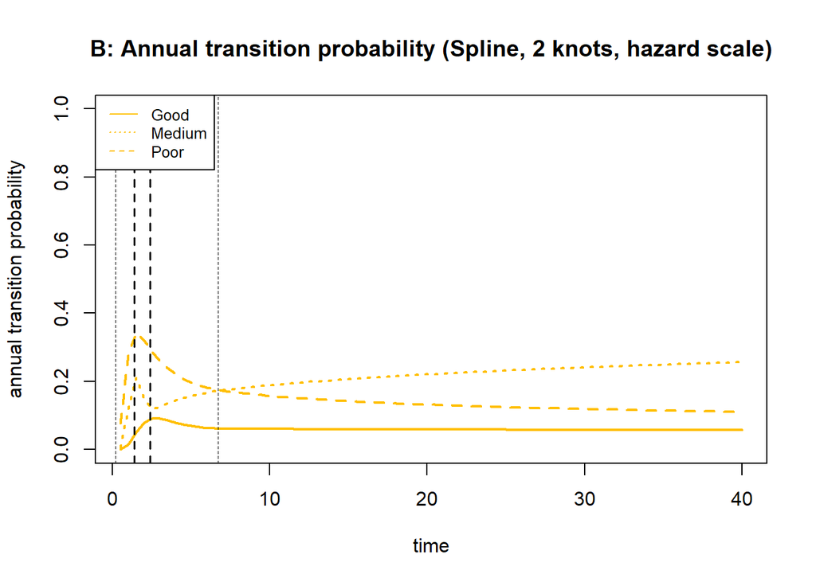

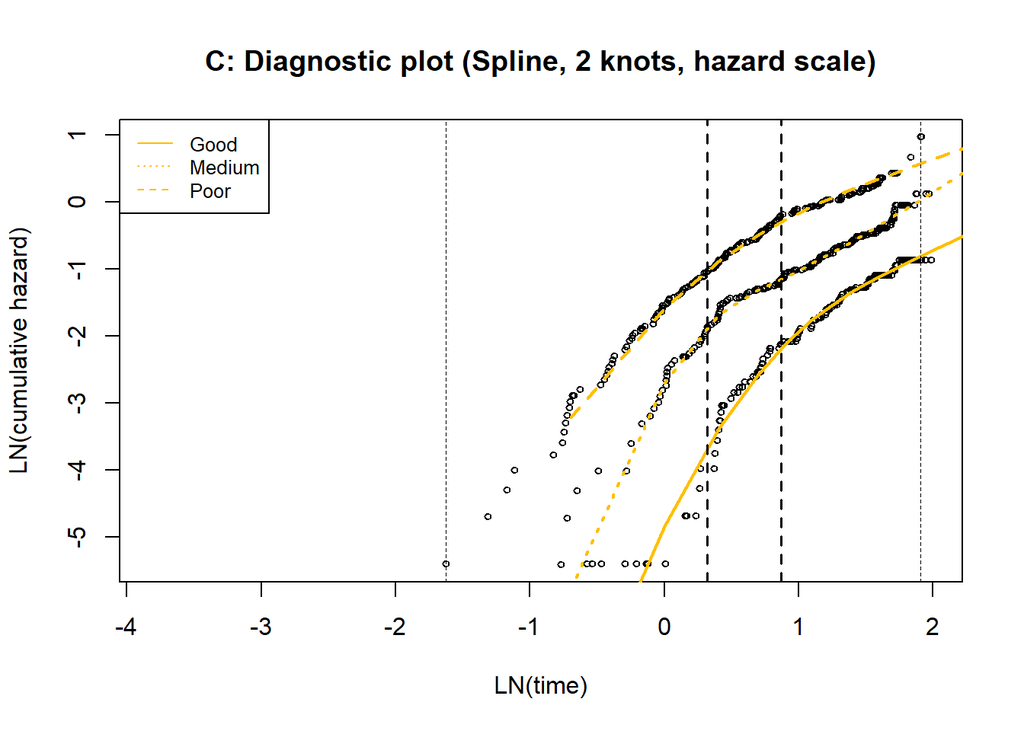

## 5.3 Spline odds 1 knot

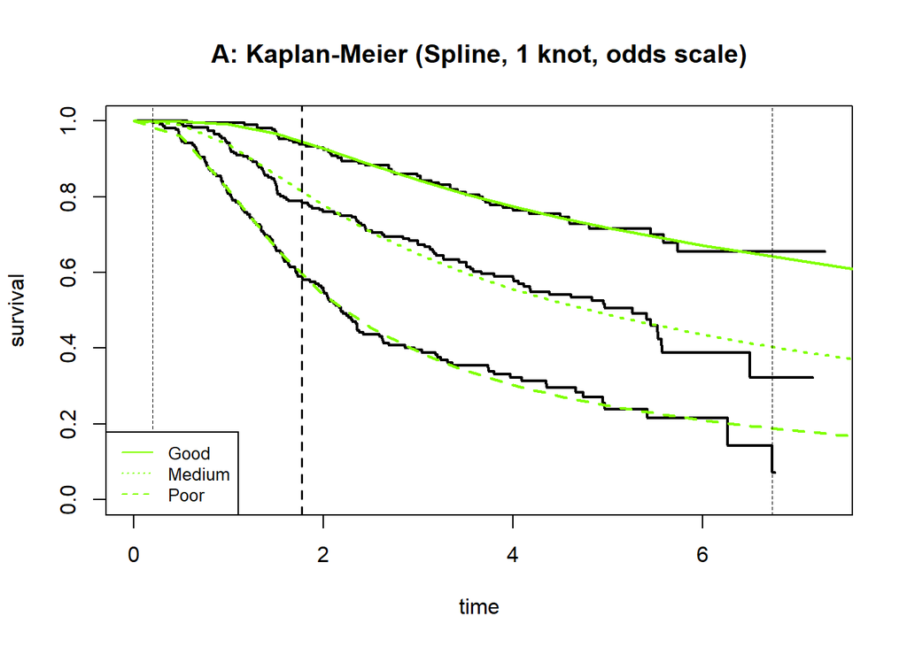

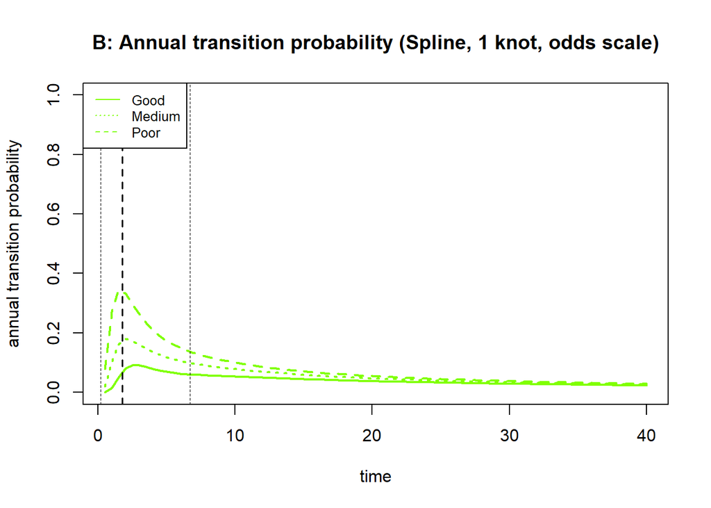

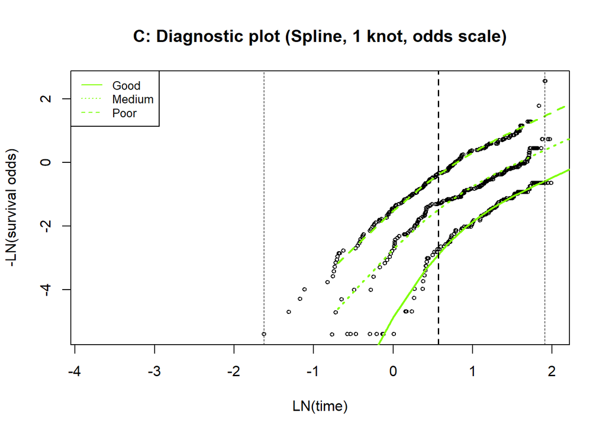

## 5.4 Spline odds 2 knots

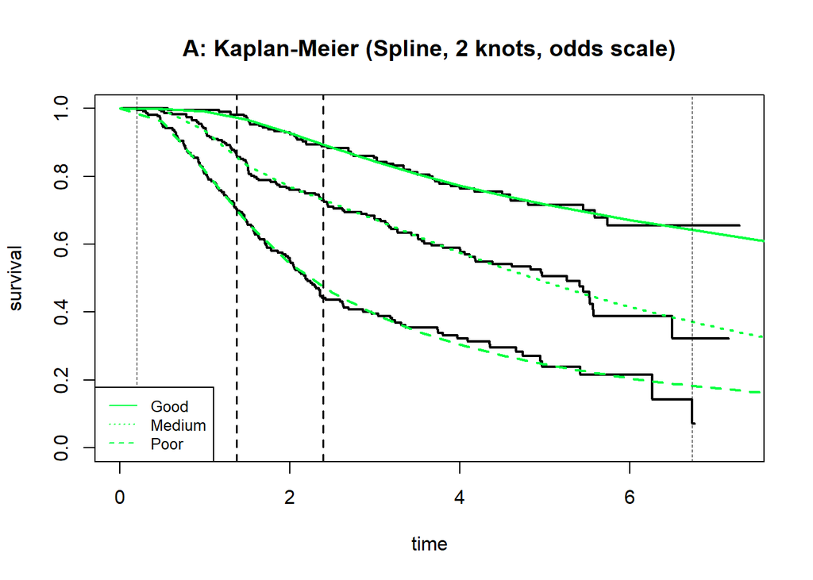

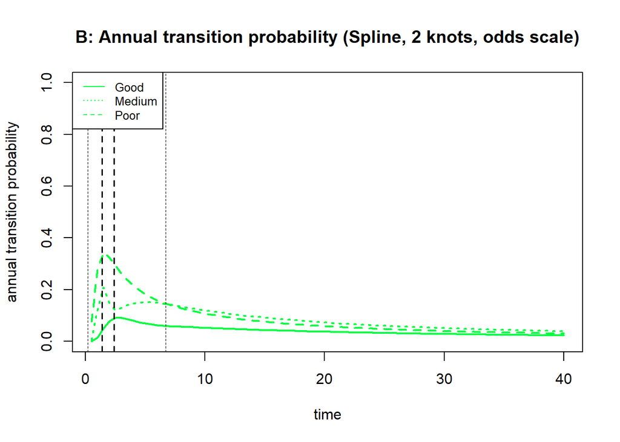

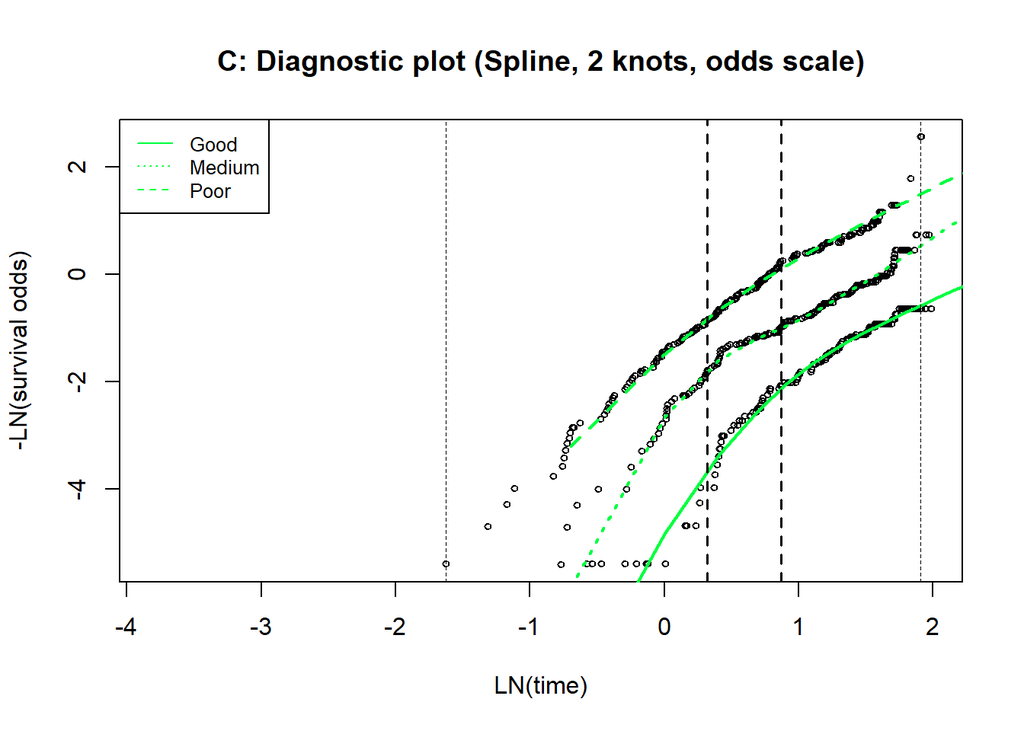

## 5.5 Spline normal 1 knot

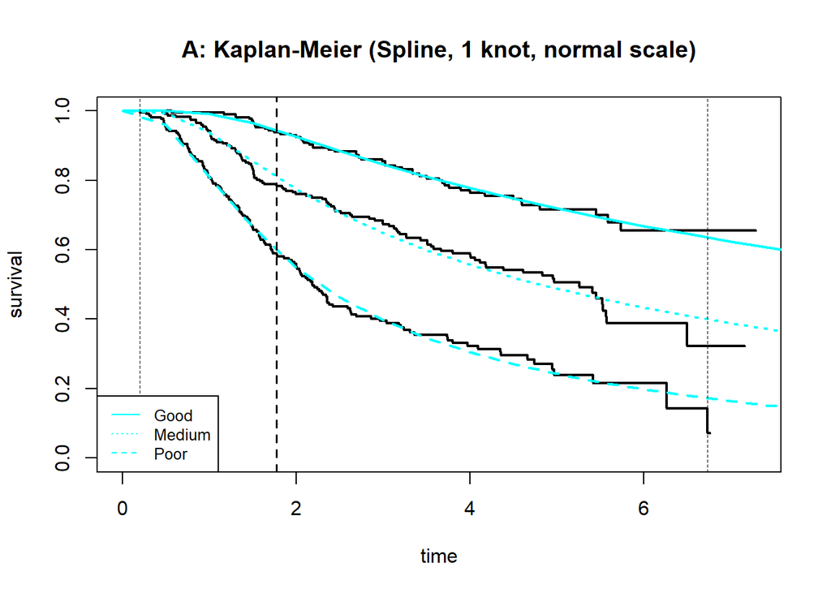

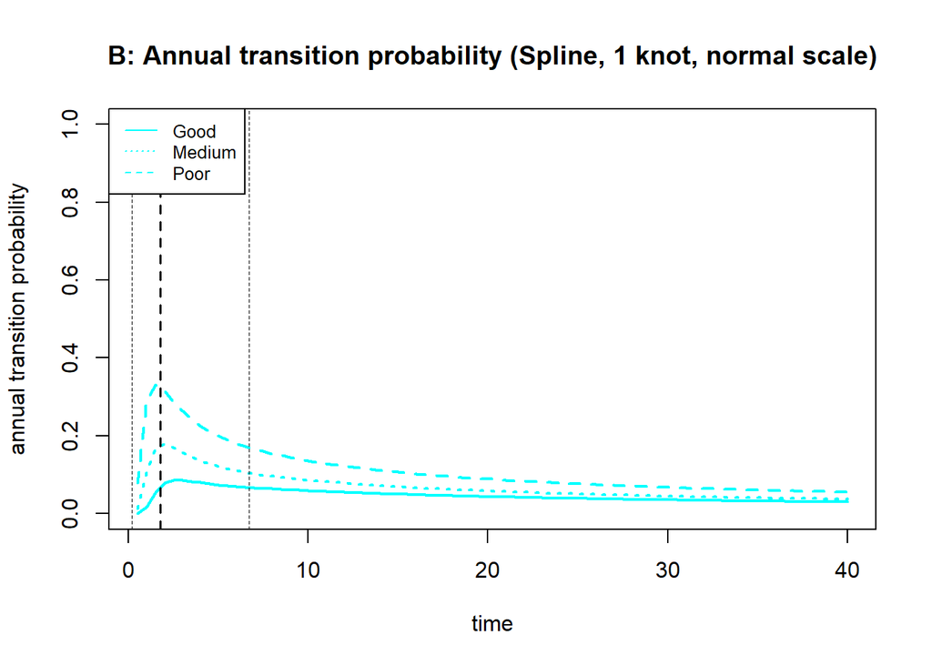

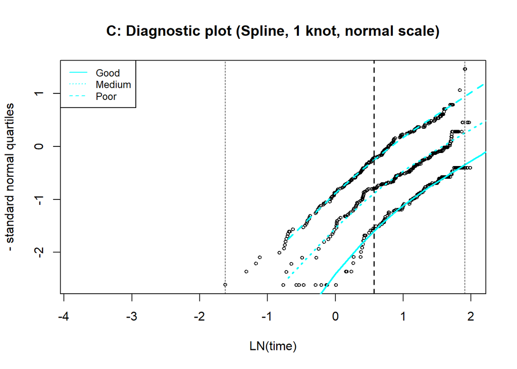

## 5.6 Spline normal 2 knots

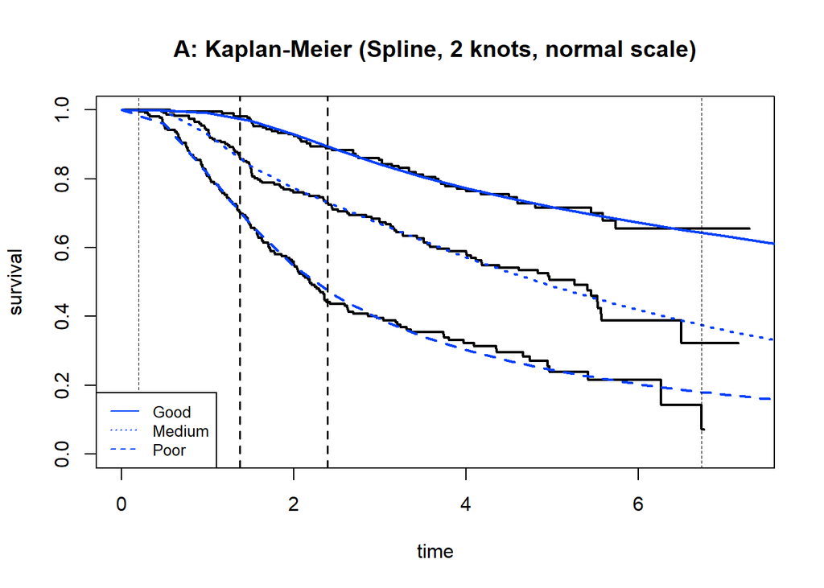

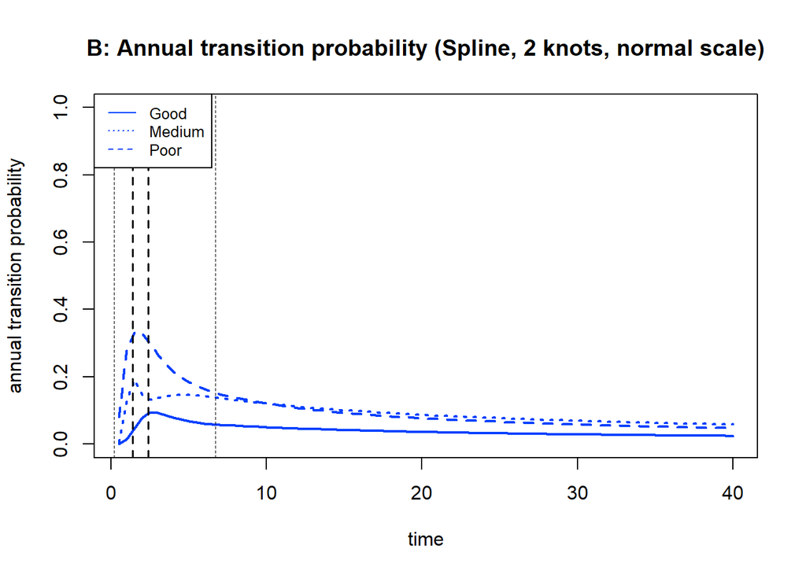

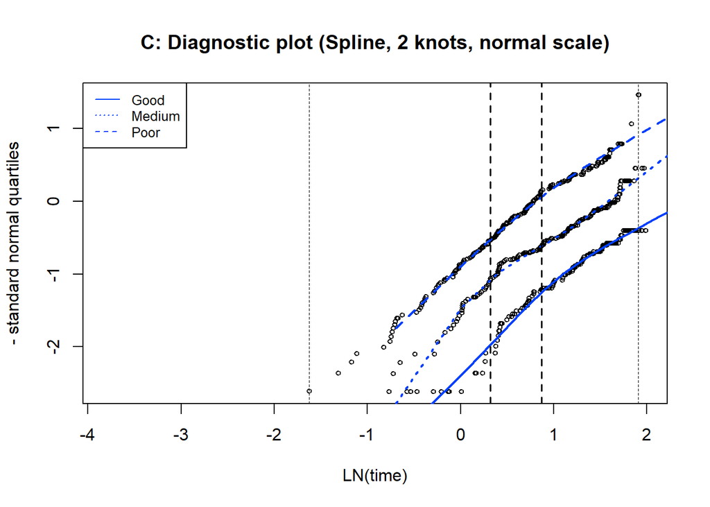

# 6 Validity of long-term extrapolation?

What model(s) is/are more appropriate for long-term extrapolation? Are/is the selected model(s) plausible in comparison with general population mortality?

## 6.1 Group Good

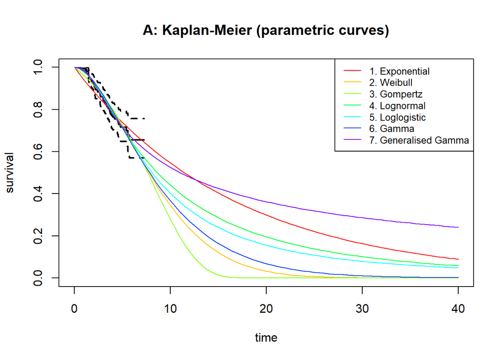

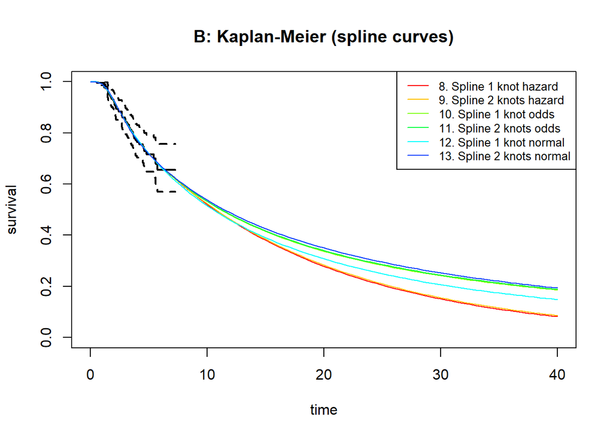

T= 0

T= 1

T= 2

T= 3

T= 4

T= 5

T= 10

T= 15

T= 20

T= 25

T= 30

T= 35

1. Exponential

1

0.941

0.886

0.834

0.785

0.739

0.547

0.404

0.299

0.221

0.163

0.121

2. Weibull

1

0.978

0.932

0.870

0.797

0.719

0.345

0.122

0.033

0.007

0.001

0.000

3. Gompertz

1

0.962

0.917

0.863

0.801

0.729

0.280

0.015

0.000

0.000

0.000

0.000

4. Lognormal

1

0.986

0.933

0.861

0.785

0.713

0.441

0.287

0.196

0.139

0.102

0.076

5. Loglogistic

1

0.980

0.932

0.865

0.789

0.712

0.403

0.240

0.156

0.108

0.080

0.061

6. Gamma

1

0.982

0.935

0.869

0.793

0.714

0.367

0.165

0.069

0.027

0.011

0.004

7. Generalised Gamma

1

0.991

0.928

0.849

0.778

0.717

0.526

0.425

0.362

0.319

0.286

0.261

8. Spline 1 knot hazard

1

0.992

0.927

0.843

0.774

0.719

0.521

0.381

0.279

0.205

0.151

0.111

9. Spline 2 knots hazard

1

0.992

0.928

0.843

0.774

0.719

0.523

0.384

0.283

0.210

0.156

0.116

10. Spline 1 knot odds

1

0.992

0.927

0.843

0.774

0.718

0.532

0.415

0.338

0.283

0.242

0.211

11. Spline 2 knots odds

1

0.992

0.928

0.843

0.774

0.718

0.533

0.418

0.340

0.285

0.245

0.213

12. Spline 1 knot normal

1

0.992

0.926

0.847

0.778

0.719

0.515

0.391

0.308

0.250

0.207

0.174

13. Spline 2 knots normal

1

0.992

0.929

0.842

0.773

0.718

0.538

0.426

0.350

0.295

0.253

0.220

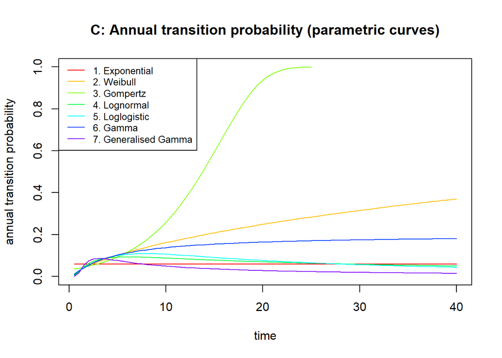

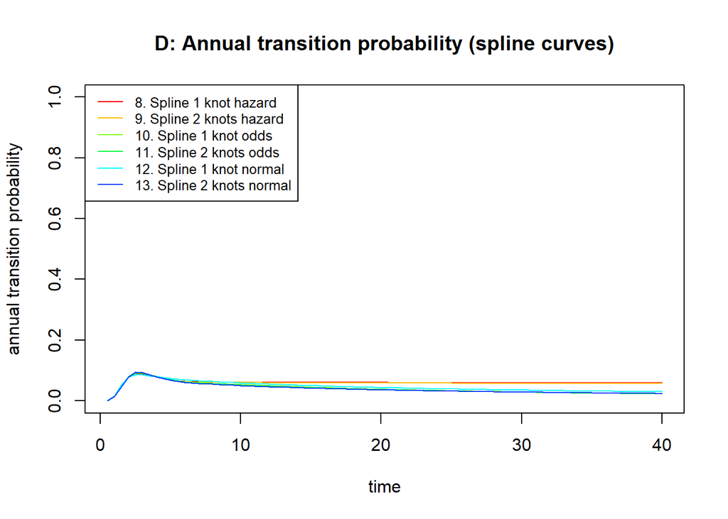

Min

Q1

Median

Q3

Max

1. Exponential

0.0585969

0.0585969

0.0585969

0.0585969

0.0585969

2. Weibull

0.0134926

0.1641610

0.2507474

0.3170860

0.3704265

3. Gompertz

0.0358674

0.1289836

0.4243279

0.8897705

1.0000000

4. Lognormal

0.0035242

0.0564742

0.0669435

0.0816466

0.0935926

5. Loglogistic

0.0108361

0.0535545

0.0698593

0.0936004

0.1092076

6. Gamma

0.0091337

0.1390115

0.1644832

0.1750177

0.1806585

7. Generalised Gamma

0.0003592

0.0189735

0.0268357

0.0454799

0.0860838

8. Spline 1 knot hazard

0.0006045

0.0592047

0.0598816

0.0610069

0.0907018

9. Spline 2 knots hazard

0.0006430

0.0576382

0.0585136

0.0599758

0.0911975

10. Spline 1 knot odds

0.0006235

0.0281280

0.0364731

0.0503972

0.0907451

11. Spline 2 knots odds

0.0006730

0.0277991

0.0360401

0.0499037

0.0912259

12. Spline 1 knot normal

0.0003052

0.0345981

0.0424906

0.0555438

0.0858716

13. Spline 2 knots normal

0.0011199

0.0281489

0.0349746

0.0469783

0.0942191

## 6.2 Group Medium

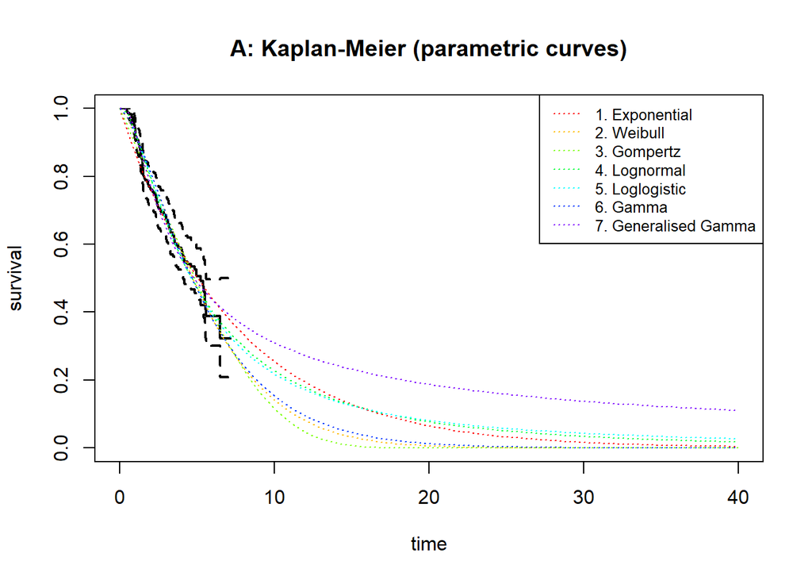

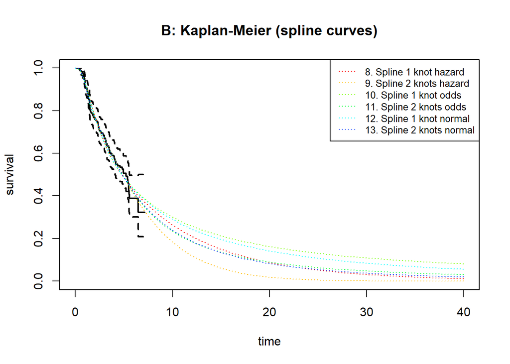

T= 0

T= 1

T= 2

T= 3

T= 4

T= 5

T= 10

T= 15

T= 20

T= 25

T= 30

T= 35

1. Exponential

1

0.872

0.761

0.663

0.578

0.505

0.255

0.128

0.065

0.033

0.016

0.008

2. Weibull

1

0.923

0.811

0.693

0.578

0.474

0.141

0.032

0.006

0.001

0.000

0.000

3. Gompertz

1

0.898

0.794

0.689

0.586

0.486

0.117

0.007

0.000

0.000

0.000

0.000

4. Lognormal

1

0.935

0.797

0.668

0.560

0.473

0.228

0.126

0.077

0.050

0.034

0.024

5. Loglogistic

1

0.927

0.801

0.673

0.561

0.468

0.218

0.124

0.081

0.057

0.043

0.034

6. Gamma

1

0.930

0.813

0.689

0.572

0.469

0.154

0.045

0.013

0.003

0.001

0.000

7. Generalised Gamma

1

0.937

0.774

0.648

0.556

0.488

0.310

0.232

0.187

0.158

0.138

0.122

8. Spline 1 knot hazard

1

0.939

0.782

0.652

0.558

0.486

0.265

0.150

0.087

0.052

0.031

0.019

9. Spline 2 knots hazard

1

0.935

0.766

0.673

0.579

0.490

0.184

0.061

0.018

0.005

0.001

0.000

10. Spline 1 knot odds

1

0.939

0.778

0.648

0.556

0.489

0.301

0.213

0.162

0.131

0.109

0.093

11. Spline 2 knots odds

1

0.935

0.769

0.673

0.576

0.489

0.235

0.136

0.089

0.063

0.048

0.037

12. Spline 1 knot normal

1

0.938

0.775

0.648

0.557

0.488

0.290

0.195

0.141

0.107

0.084

0.067

13. Spline 2 knots normal

1

0.930

0.773

0.669

0.572

0.489

0.240

0.135

0.083

0.054

0.037

0.026

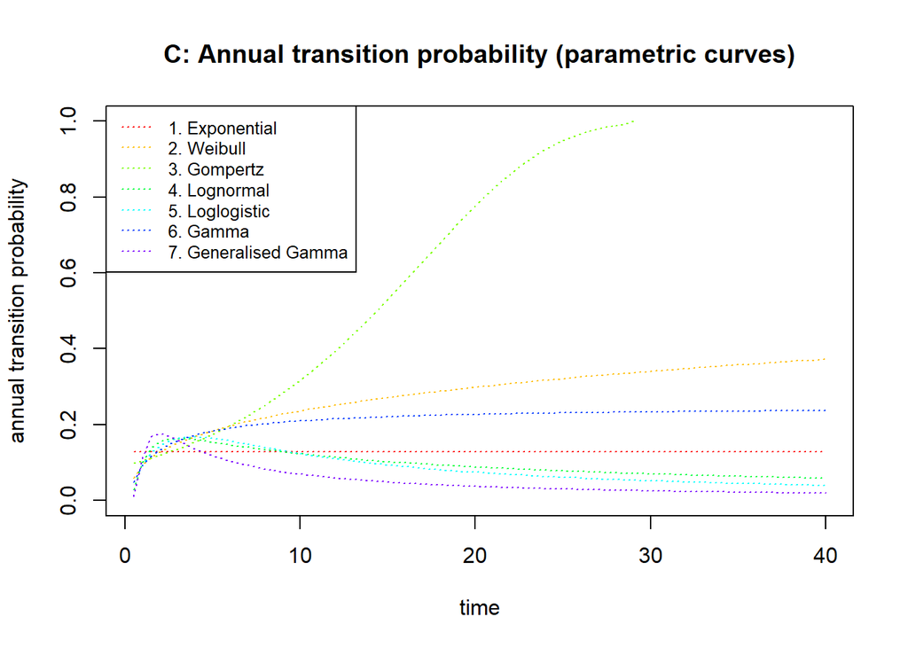

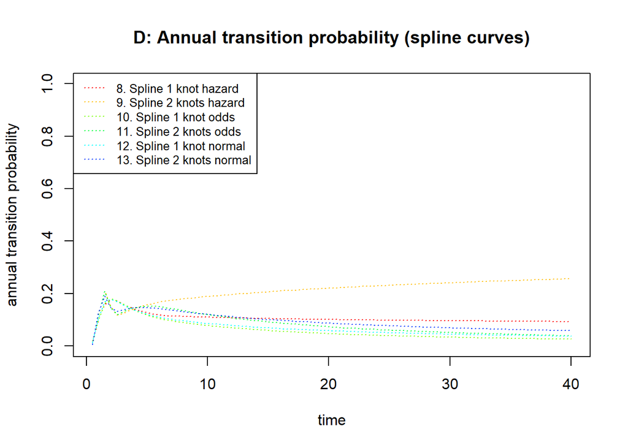

Min

Q1

Median

Q3

Max

1. Exponential

0.1278820

0.1278820

0.1278820

0.1278820

0.1278820

2. Weibull

0.0591011

0.2381968

0.2998605

0.3413129

0.3724339

3. Gompertz

0.0986811

0.2373335

0.5186913

0.8609606

1.0000000

4. Lognormal

0.0282952

0.0692226

0.0866936

0.1171810

0.1629587

5. Loglogistic

0.0398205

0.0508351

0.0719824

0.1148545

0.1671681

6. Gamma

0.0480016

0.2105085

0.2273394

0.2338781

0.2372976

7. Generalised Gamma

0.0109341

0.0249143

0.0360207

0.0648290

0.1772175

8. Spline 1 knot hazard

0.0207293

0.0962139

0.1005759

0.1085803

0.1758852

9. Spline 2 knots hazard

0.0061802

0.1921445

0.2213455

0.2415959

0.2565416

10. Spline 1 knot odds

0.0196172

0.0330411

0.0459973

0.0747733

0.1799958

11. Spline 2 knots odds

0.0057632

0.0502183

0.0708612

0.1151671

0.2083176

12. Spline 1 knot normal

0.0128862

0.0444913

0.0569747

0.0828185

0.1788613

13. Spline 2 knots normal

0.0053472

0.0683352

0.0854055

0.1171708

0.1907920

## 6.3 Group Poor

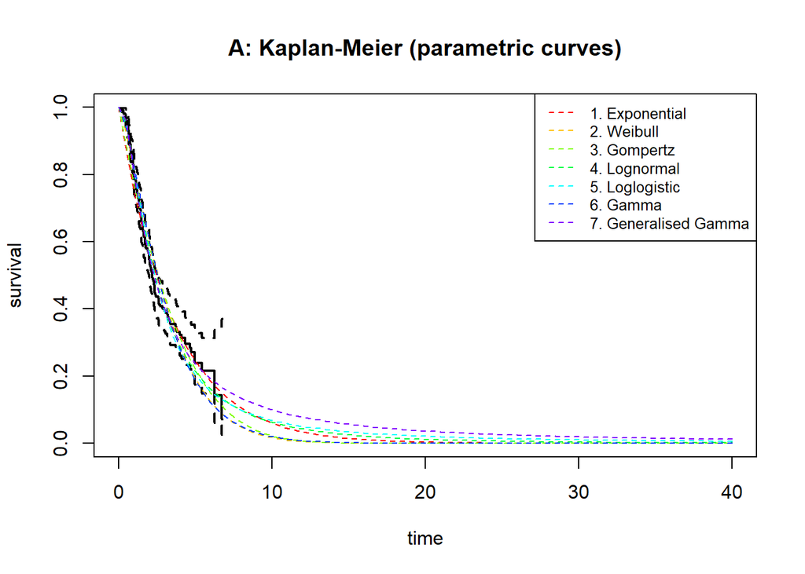

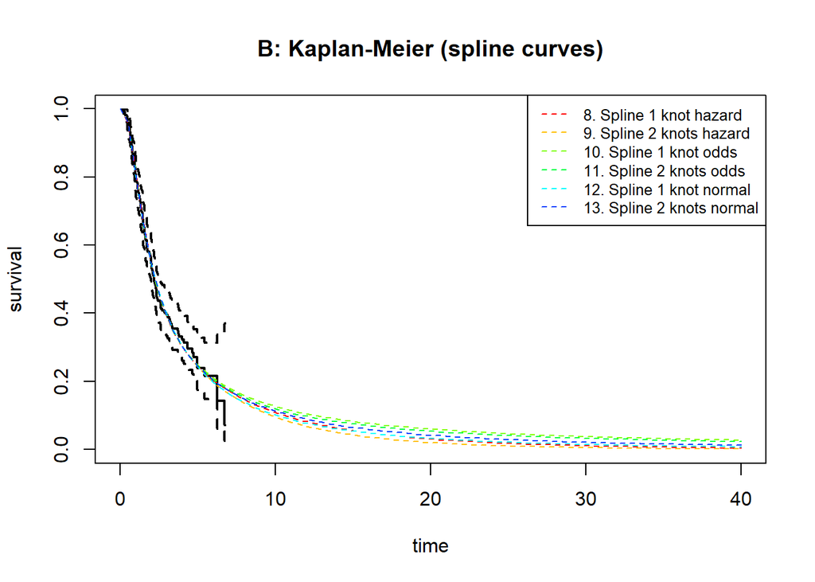

T= 0

T= 1

T= 2

T= 3

T= 4

T= 5

T= 10

T= 15

T= 20

T= 25

T= 30

T= 35

1. Exponential

1

0.755

0.570

0.430

0.325

0.245

0.060

0.015

0.004

0.001

0.000

0.000

2. Weibull

1

0.817

0.608

0.430

0.292

0.193

0.017

0.001

0.000

0.000

0.000

0.000

3. Gompertz

1

0.776

0.588

0.436

0.315

0.221

0.022

0.001

0.000

0.000

0.000

0.000

4. Lognormal

1

0.820

0.572

0.401

0.289

0.214

0.063

0.025

0.012

0.006

0.004

0.002

5. Loglogistic

1

0.819

0.568

0.389

0.275

0.203

0.069

0.034

0.021

0.014

0.010

0.008

6. Gamma

1

0.829

0.605

0.420

0.283

0.187

0.020

0.002

0.000

0.000

0.000

0.000

7. Generalised Gamma

1

0.810

0.555

0.399

0.302

0.237

0.100

0.057

0.037

0.026

0.019

0.015

8. Spline 1 knot hazard

1

0.822

0.545

0.390

0.301

0.244

0.109

0.056

0.031

0.018

0.011

0.007

9. Spline 2 knots hazard

1

0.817

0.546

0.396

0.305

0.243

0.096

0.043

0.021

0.010

0.005

0.003

10. Spline 1 knot odds

1

0.820

0.542

0.390

0.303

0.248

0.127

0.082

0.060

0.047

0.038

0.032

11. Spline 2 knots odds

1

0.817

0.544

0.393

0.304

0.246

0.120

0.075

0.054

0.041

0.033

0.027

12. Spline 1 knot normal

1

0.811

0.549

0.398

0.305

0.242

0.102

0.054

0.033

0.021

0.015

0.011

13. Spline 2 knots normal

1

0.815

0.546

0.392

0.303

0.245

0.113

0.065

0.042

0.029

0.021

0.016

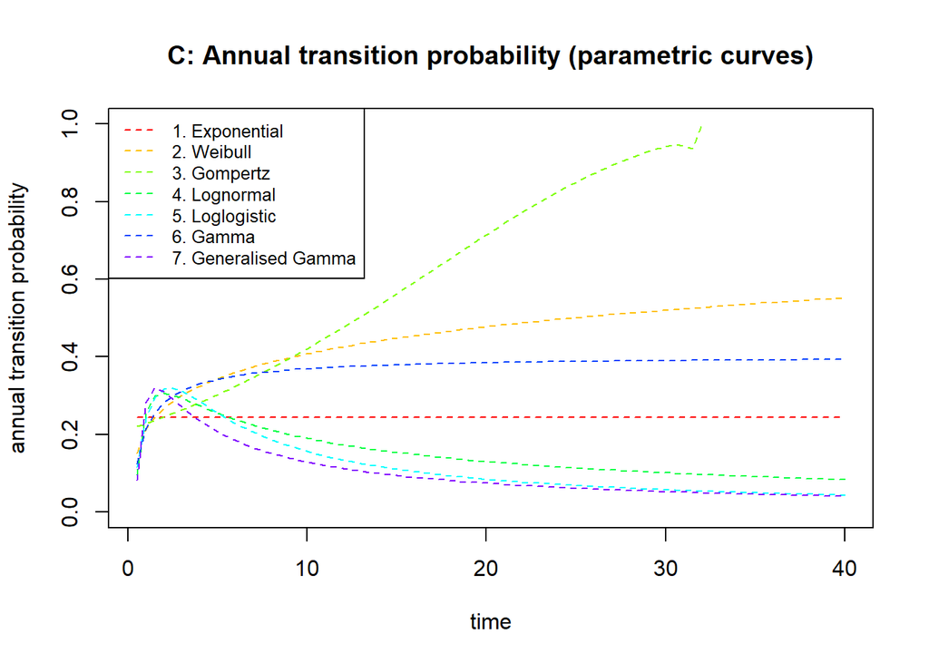

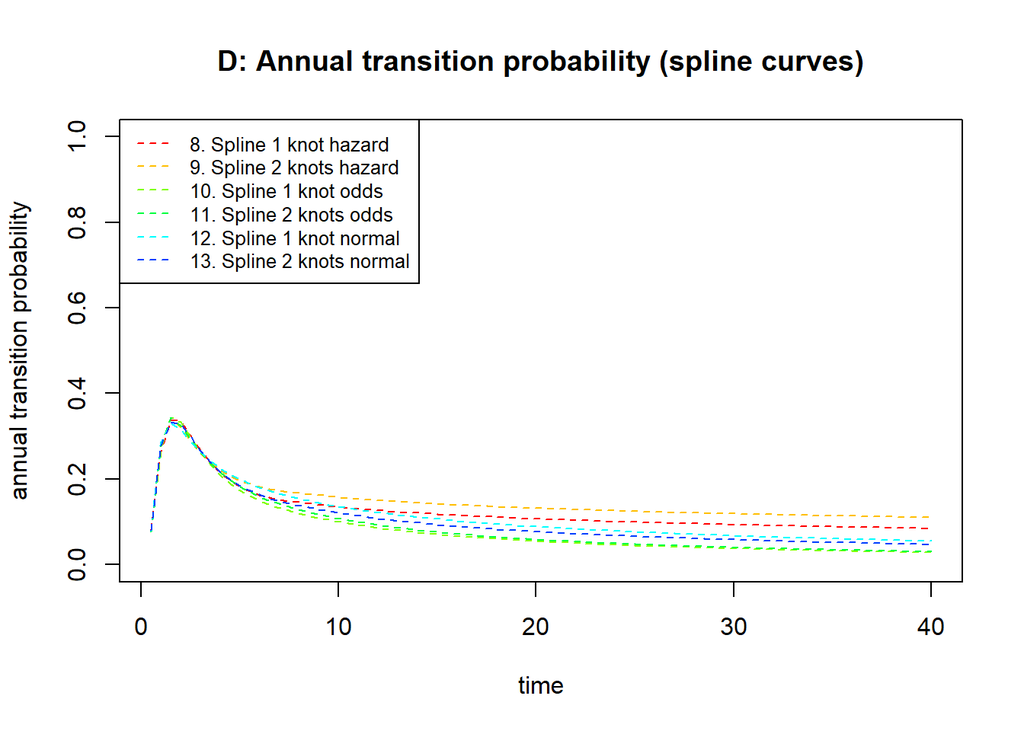

Min

Q1

Median

Q3

Max

1. Exponential

0.2449482

0.2449482

0.2449482

0.2449482

0.2449482

2. Weibull

0.1510049

0.4105396

0.4790497

0.5216154

0.5520052

3. Gompertz

0.2203222

0.3769816

0.6007991

0.8316903

1.0000000

4. Lognormal

0.0836825

0.0995548

0.1272985

0.1834832

0.3065423

5. Loglogistic

0.0437409

0.0573187

0.0838677

0.1475772

0.3193673

6. Gamma

0.1253666

0.3701740

0.3852505

0.3907361

0.3935243

7. Generalised Gamma

0.0407810

0.0522176

0.0736609

0.1223572

0.3209103

8. Spline 1 knot hazard

0.0815213

0.0926812

0.1057981

0.1319033

0.3389077

9. Spline 2 knots hazard

0.0766259

0.1181717

0.1307978

0.1549084

0.3434543

10. Spline 1 knot odds

0.0285342

0.0372365

0.0541059

0.0944228

0.3440970

11. Spline 2 knots odds

0.0305654

0.0399116

0.0580356

0.1012316

0.3435620

12. Spline 1 knot normal

0.0552128

0.0671541

0.0865712

0.1304175

0.3307356

13. Spline 2 knots normal

0.0473655

0.0578940

0.0764795

0.1153902

0.3323350